# IPython Notebookで始めるデータ分析と可視化

[figure not shown]

# 自己紹介

- 名前 : 杜 世橋 (@lucidfrontier.45)
- mail :

## 今やっていること

- [フリービット](http://www.freebit.com/)でMVNOのトラッフィクデータを中心した分析
  - **pythonの布教に成功**
  - Hadoop + PyPy, MongoDB, Sparkなども使用
- SmartWatermark(仮)の技術顧問

# 本日のお題

*IPython Notebookを使ってお手軽データ分析*

# IPython Notebookとは何か

- ipythonをブラウザ経由で叩けるようにするいipython本体の機能
- 通信部分にWebSocketとtornadoを使用している
- ついつい書き散らかしがちな日々のデータ分析コードを整理するモチベーションがアップする。
- コードと結果やplotの画像がインラインで表示されるがめ、より対話的な分析が可能 -> 集計、分析、可視化をすべてまとめたり、ディスカッション中にリアルタイムで検証もできる
- markdownによるドキュメント機能が充実していて画像の取り込みやLaTexとmathjax.jsを利用して数式も表示できる
- pandocを利用してnotebookを様々な形式のドキュメントにexportできる(nbconverter)

## nbviewerにてシェアされているnotebookが閲覧できる

```python
from IPython.display import HTML
HTML('<iframe src=http://nbviewer.ipython.org/ width=800 height=500></iframe>')
```

[interactive chart not shown]

# 今回の環境

## OS, Python

- OS : Ubuntu 14.04
- Python 2.7.6
- NumPy, Scipy, Matplotlib : apt-getでinstall
- その他pandoc, mongodb, redisなども入れる。

## IPython

以下のコマンドでIPython本体と大抵の関連パッケージが入る

```bash
$ sudo pip install ipython[all] --upgrade
```

2014/08時点でのIPythonの最新版は2.1

Windowsの場合や古いCentOS6などでは手っ取り早く[Anaconda](https://store.continuum.io/cshop/anaconda/)を使用して入れてしまうのも良い。

今回の環境のvagrant boxファイルは[こちら](https://vagrantcloud.com/frontier45/ubuntu-trusty-ipnotebook/version/1/provider/virtualbox.box)。

## 起動

以下のコマンドで起動

```bash
$ ipython notebook
```

## よく使うオプション

- `--pylab=inline` : numpyやmatplotlibなどがimportされているmatlab-likeな環境で起動、画像はそのままcell内に表示
- `--ip=, --port=` : bindするアドレスとポートを指定。デフォルトは`(ip, port) = (localhost, 8888)`
- `--no-browser` : 起動時と同時にブラウザで表示しない
- `--certfile=` : Notebookサーバーにパスワードを掛けることができる。アクセス方式もHTTPSに変わる。

## おすすめ起動コマンド

```bash
$ nohup ipython notebook --pylab=inline --ip=0.0.0.0 --no-browser >> ~/nbserver.log 2>&1 & echo $! > ipython_notebook.pid
```

オプションはコマンドで指定する以外にconfigファイルに各方法もある。詳しくは[公式doc](http://ipython.org/ipython-doc/2/config/index.html)を参照。

# 使い方

ブラウザからipythonと同じようにpythonのコードを書いて使用するだけ!

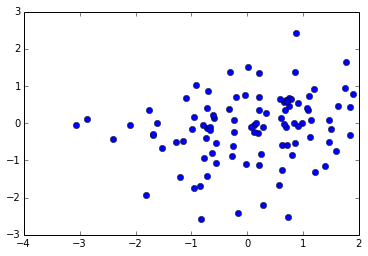

```python
import numpy as np
x = np.random.randn(100, 2)
plot(x[:,0], x[:, 1], "o")
```

## 文字と画像を大きくする

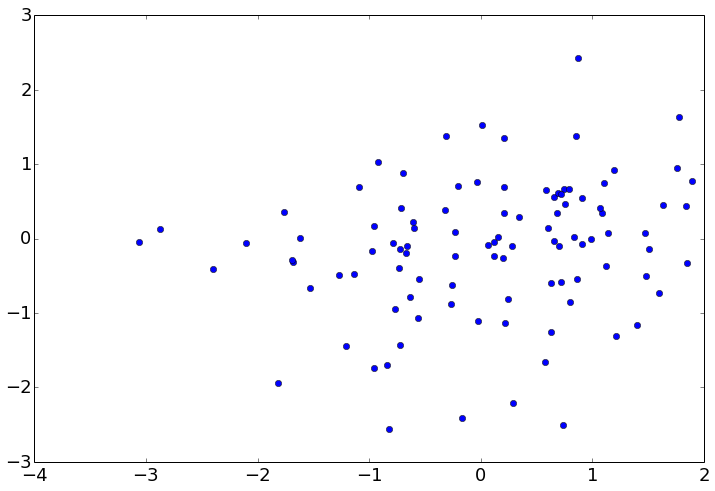

```python
pylab.rcParams["font.size"] = 18
fig = plt.figure(figsize=(12, 8))
plot(x[:,0], x[:, 1], "o")
```

# sklearnで機械学習機械学習

```python
from sklearn import datasets, decomposition, ensemble
iris = datasets.load_iris()
X = iris.data
Y = iris.target
model = ensemble.RandomForestClassifier(n_estimators=100, n_jobs=-1).fit(X, Y)
model.score(X, Y)
```

```
1.0
```

```python
labels = model.predict(X)
print labels
print Y
```

```
[0 0 0 0 0 0 0 0 0 0 0 0 0 0 0 0 0 0 0 0 0 0 0 0 0 0 0 0 0 0 0 0 0 0 0 0 0
 0 0 0 0 0 0 0 0 0 0 0 0 0 1 1 1 1 1 1 1 1 1 1 1 1 1 1 1 1 1 1 1 1 1 1 1 1
 1 1 1 1 1 1 1 1 1 1 1 1 1 1 1 1 1 1 1 1 1 1 1 1 1 1 2 2 2 2 2 2 2 2 2 2 2
 2 2 2 2 2 2 2 2 2 2 2 2 2 2 2 2 2 2 2 2 2 2 2 2 2 2 2 2 2 2 2 2 2 2 2 2 2
 2 2]
[0 0 0 0 0 0 0 0 0 0 0 0 0 0 0 0 0 0 0 0 0 0 0 0 0 0 0 0 0 0 0 0 0 0 0 0 0
 0 0 0 0 0 0 0 0 0 0 0 0 0 1 1 1 1 1 1 1 1 1 1 1 1 1 1 1 1 1 1 1 1 1 1 1 1
 1 1 1 1 1 1 1 1 1 1 1 1 1 1 1 1 1 1 1 1 1 1 1 1 1 1 2 2 2 2 2 2 2 2 2 2 2
 2 2 2 2 2 2 2 2 2 2 2 2 2 2 2 2 2 2 2 2 2 2 2 2 2 2 2 2 2 2 2 2 2 2 2 2 2
 2 2]
```

# pandasのDataFrameは自動的に表みたいに表示される

```python
import pandas as pd
names = [iris.target_names[i] for i in iris.target]
iris_df = pd.DataFrame(data=X, index=names, columns=iris.feature_names)
iris_df.index.name = "species"
random_indexes = np.arange(len(X))
np.random.shuffle(random_indexes)
# iris_df[random_indexes]
iris_df.ix[random_indexes][:10]
```

| species | sepal length (cm) | sepal width (cm) | petal length (cm) | petal width (cm) |
| --- | --- | --- | --- | --- |
| virginica | 7.3 | 2.9 | 6.3 | 1.8 |
| versicolor | 5.5 | 2.5 | 4.0 | 1.3 |
| versicolor | 6.2 | 2.9 | 4.3 | 1.3 |
| virginica | 7.1 | 3.0 | 5.9 | 2.1 |
| setosa | 5.0 | 3.5 | 1.6 | 0.6 |
| versicolor | 6.3 | 2.3 | 4.4 | 1.3 |
| virginica | 5.8 | 2.7 | 5.1 | 1.9 |
| versicolor | 5.7 | 3.0 | 4.2 | 1.2 |
| setosa | 5.8 | 4.0 | 1.2 | 0.2 |
| versicolor | 7.0 | 3.2 | 4.7 | 1.4 |

10 rows × 4 columns

# DBにアクセス

## Redis

```python
import redis
r = redis.StrictRedis(host='localhost', port=6379, db=0)
r.set('foo', 'bar')
r.get('foo')
```

```
'bar'
```

## MongoDB

```python
import pymongo
con = pymongo.MongoClient(host="localhost")
col = con["testdb"]["testcol"]
col.insert({"hoge":"fuga"})
list(col.find())
```

```
[{u'_id': ObjectId('53d741e995babe0b62286cd2'), u'hoge': u'fuga'}]
```

## MongoDBのレコードをDataFrameに入れる

```python
col = con["testdb"]["iris"]
iris_dat = pd.DataFrame(list(col.find({},{"_id":0})))
iris_dat[:10]
```

|  | petal length (cm) | petal width (cm) | sepal length (cm) | sepal width (cm) | species |
| --- | --- | --- | --- | --- | --- |
| 0 | 1.4 | 0.2 | 5.1 | 3.5 | setosa |
| 1 | 1.4 | 0.2 | 4.9 | 3.0 | setosa |
| 2 | 1.3 | 0.2 | 4.7 | 3.2 | setosa |
| 3 | 1.5 | 0.2 | 4.6 | 3.1 | setosa |
| 4 | 1.4 | 0.2 | 5.0 | 3.6 | setosa |
| 5 | 1.7 | 0.4 | 5.4 | 3.9 | setosa |
| 6 | 1.4 | 0.3 | 4.6 | 3.4 | setosa |
| 7 | 1.5 | 0.2 | 5.0 | 3.4 | setosa |
| 8 | 1.4 | 0.2 | 4.4 | 2.9 | setosa |
| 9 | 1.5 | 0.1 | 4.9 | 3.1 | setosa |

10 rows × 5 columns

# 並列計算がしたい

- built-inの`multiprocessing`モジュールを使用する
- `IPython.parallel`を使用する
- PySparkを使用する
- impylaを使用する

## multiprocessing

変なエラーでつまづきました。どうやら***__main__からでないと使用できない***らしい。

```python
HTML('<iframe src=https://docs.python.org/2/library/multiprocessing.html#introduction width=800 height=500></iframe>')
```

[interactive chart not shown]

## IPython.parallel

よくわからん 以下のページを参照

```python
HTML('<iframe src=http://ipython.org/ipython-doc/2/parallel/parallel_intro.html width=800 height=500></iframe>')
```

[interactive chart not shown]

## PySpark

```python
"""
この内容は
~/.ipython/profile_default/startup/00-pyspark-setup.py
あたりに書いておく便利
"""

# Configure the necessary Spark environment
import os
os.environ['SPARK_HOME'] = '/opt/spark/'

# And Python path
import sys
sys.path.insert(0, '/opt/spark/python')
sys.path.insert(0, '/opt/spark/python/lib/py4j-0.8.1-src.zip')
```

```python
# create Spark Context
from pyspark import SparkConf, SparkContext
conf = SparkConf().setMaster("local").set("spark.executer.memory", "256m")
sc = SparkContext(conf=conf)
```

```python
distData = sc.parallelize(range(10))
distData.map(lambda x:x**2).reduce(lambda x,y:x+y)
```

```
285
```

このノートはSparkContextを掴みっぱなしなので忘れずにshutdownしておくこと

## impyla

めんどくさいので試してません。[github](https://github.com/cloudera/impyla)でも見てどうにかしてください。

# notebookを他の形式にexport

pandocを使用して`html`, `latex`, `rst`など様々フォーマットに変換できる

```bash
$ ipython nbconvert --to FORMAT notebook.ipynb
```

Reveal.jsを使用した`slides`にも変換できる。詳しくは公式docを(ry

```python
HTML("<iframe width=800 height=500 src=http://ipython.org/ipython-doc/1/interactive/nbconvert.html></iframe>")
```

[interactive chart not shown]

# 参考

## 公式系

- IPython公式サイト http://ipython.org/
- githubにあるNotebookギャラリ https://github.com/ipython/ipython/wiki/A-gallery-of-interesting-IPython-Notebooks
- nbviewer http://nbviewer.ipython.org/

# クラウド系

- [Azureでも使えるみたいだよ](http://azure.microsoft.com/ja-jp/documentation/articles/virtual-machines-python-ipython-notebook/)
- [0.27ドル/時から始めるIPython Notebook in EC2](http://badhessian.org/2013/11/cluster-computing-for-027hr-using-amazon-ec2-and-ipython-notebook/)

### (一応)会社の宣伝

**ServersMan@VPSなら月ワンコインでIPython Notebookのサーバーができるよ!**

```python
HTML("<iframe width=800 height=500 src=http://dream.jp/vps/></iframe>")
```

[interactive chart not shown]